# Project Name : Air Quality Prediction

# Domain Background

In early 2011, officials reported that pollution in Italy was reaching crisis levels. What's particularly troublesome is particle pollution that pervades Italy, and accounts for breathing and heart problems, causing a whopping 9% of deaths of Italians over the age of 30. New report finds that air pollution is the single biggest environmental health risk in Europe, causing hundreds of thousands of premature deaths. Particulate matter, ozone, nitrogen dioxide. Europe’s air quality is significantly threatened by these pollutants, mostly in urban centres Air quality is a significant concern for both healthy population and people suffering for different pathologies. Long or even short term exposure to significant pollution levels have been associated with the development or worsening of multiple pathologies ranging from Asthma to Lung Cancer . Air quality patterns may significantly vary in space and time due to complex fluid dynamic effects occurring in the city landscape or to the hourly, daily and seasonal variation of human activities. However, most of the national states rely on the operation of networks of certified air quality monitoring stations in order to detect and monitor air quality in cities. Unfortunately, the average low spatial density of such networks do not permit to achieve the required resolution.

# Problem Statement

To check the quality of air using ‘Air Quality Chemical Multisensor Device’ by finding the R^2 score and coefficient of regression using different regression models and the best model is selected to evaluate the Air Quality.

# Dataset

# Importing Libraries

```python
import numpy as np
import pandas as pd
import matplotlib.pyplot as plt
import seaborn as sns
```

# Dataset Structure & Description

In this project I have used 15 attributes and around 9300 trained and test data to evaluate the R-squared score and this coefficient is found out by using different Regression methods.The dataset used are shown in the below:

.Date -DD/MM/YY .Time -HH.MM.SS .CO(GT) - True hourly averaged concentration CO inmg/m^3 .PT08.S1(CO) - PT08.S1 (tin oxide) hourly averaged sensorresponse (nominally COtargeted) .NMHC(GT) - True hourly averaged overall Non MetanicHydroCarbons concentrationinmicrog/m^3 .C6H6(GT) - True hourly averaged Benzene concentration in microg/m^3 .PT08.S2(NMHC) - PT08.S2 (titania) hourly averaged sensor response (nominally NMHCtargeted) .NOx(GT) - True hourly averaged NOx concentration inppb .PT08.S3(NOx) - PT08.S3 (tungsten oxide) hourly averaged sensor response .NO2(GT) - True hourly averaged NO2 concentration inmicrog/m^3 .PT08.S4(NO2)- PT08.S4 (tungsten oxide) hourly averaged sensor response .PT08.S5(O3) - PT08.S5 (indium oxide) hourly averagedsensor response (nominally O3targeted) .T - Temperature in Â°C .RH - Relative Humidity (%) .AH - Absolute Humidity

# Data Extraction

Loading dataset in excel sheet

```python
df = pd.read_excel('AirQualityUCI.xlsx')
```

# Reading the data from excel

```python
df
```

|  | Date | Time | CO(GT) | PT08.S1(CO) | NMHC(GT) | C6H6(GT) | PT08.S2(NMHC) | NOx(GT) | PT08.S3(NOx) | NO2(GT) | PT08.S4(NO2) | PT08.S5(O3) | T | RH | AH |
| --- | --- | --- | --- | --- | --- | --- | --- | --- | --- | --- | --- | --- | --- | --- | --- |
| 0 | 2004-03-10 | 18:00:00 | 2.6 | 1360.00 | 150 | 11.881723 | 1045.50 | 166.0 | 1056.25 | 113.0 | 1692.00 | 1267.50 | 13.600 | 48.875001 | 0.757754 |
| 1 | 2004-03-10 | 19:00:00 | 2.0 | 1292.25 | 112 | 9.397165 | 954.75 | 103.0 | 1173.75 | 92.0 | 1558.75 | 972.25 | 13.300 | 47.700000 | 0.725487 |
| 2 | 2004-03-10 | 20:00:00 | 2.2 | 1402.00 | 88 | 8.997817 | 939.25 | 131.0 | 1140.00 | 114.0 | 1554.50 | 1074.00 | 11.900 | 53.975000 | 0.750239 |
| 3 | 2004-03-10 | 21:00:00 | 2.2 | 1375.50 | 80 | 9.228796 | 948.25 | 172.0 | 1092.00 | 122.0 | 1583.75 | 1203.25 | 11.000 | 60.000000 | 0.786713 |
| 4 | 2004-03-10 | 22:00:00 | 1.6 | 1272.25 | 51 | 6.518224 | 835.50 | 131.0 | 1205.00 | 116.0 | 1490.00 | 1110.00 | 11.150 | 59.575001 | 0.788794 |
| ... | ... | ... | ... | ... | ... | ... | ... | ... | ... | ... | ... | ... | ... | ... | ... |
| 9352 | 2005-04-04 | 10:00:00 | 3.1 | 1314.25 | -200 | 13.529605 | 1101.25 | 471.7 | 538.50 | 189.8 | 1374.25 | 1728.50 | 21.850 | 29.250000 | 0.756824 |
| 9353 | 2005-04-04 | 11:00:00 | 2.4 | 1162.50 | -200 | 11.355157 | 1027.00 | 353.3 | 603.75 | 179.2 | 1263.50 | 1269.00 | 24.325 | 23.725000 | 0.711864 |
| 9354 | 2005-04-04 | 12:00:00 | 2.4 | 1142.00 | -200 | 12.374538 | 1062.50 | 293.0 | 603.25 | 174.7 | 1240.75 | 1092.00 | 26.900 | 18.350000 | 0.640649 |
| 9355 | 2005-04-04 | 13:00:00 | 2.1 | 1002.50 | -200 | 9.547187 | 960.50 | 234.5 | 701.50 | 155.7 | 1041.00 | 769.75 | 28.325 | 13.550000 | 0.513866 |
| 9356 | 2005-04-04 | 14:00:00 | 2.2 | 1070.75 | -200 | 11.932060 | 1047.25 | 265.2 | 654.00 | 167.7 | 1128.50 | 816.00 | 28.500 | 13.125000 | 0.502804 |

9357 rows × 15 columns

```python
df.describe()
```

|  | CO(GT) | PT08.S1(CO) | NMHC(GT) | C6H6(GT) | PT08.S2(NMHC) | NOx(GT) | PT08.S3(NOx) | NO2(GT) | PT08.S4(NO2) | PT08.S5(O3) | T | RH | AH |
| --- | --- | --- | --- | --- | --- | --- | --- | --- | --- | --- | --- | --- | --- |
| count | 9357.000000 | 9357.000000 | 9357.000000 | 9357.000000 | 9357.000000 | 9357.000000 | 9357.000000 | 9357.000000 | 9357.000000 | 9357.000000 | 9357.000000 | 9357.000000 | 9357.000000 |
| mean | -34.207524 | 1048.869652 | -159.090093 | 1.865576 | 894.475963 | 168.604200 | 794.872333 | 58.135898 | 1391.363266 | 974.951534 | 9.776600 | 39.483611 | -6.837604 |
| std | 77.657170 | 329.817015 | 139.789093 | 41.380154 | 342.315902 | 257.424561 | 321.977031 | 126.931428 | 467.192382 | 456.922728 | 43.203438 | 51.215645 | 38.976670 |
| min | -200.000000 | -200.000000 | -200.000000 | -200.000000 | -200.000000 | -200.000000 | -200.000000 | -200.000000 | -200.000000 | -200.000000 | -200.000000 | -200.000000 | -200.000000 |
| 25% | 0.600000 | 921.000000 | -200.000000 | 4.004958 | 711.000000 | 50.000000 | 637.000000 | 53.000000 | 1184.750000 | 699.750000 | 10.950000 | 34.050000 | 0.692275 |
| 50% | 1.500000 | 1052.500000 | -200.000000 | 7.886653 | 894.500000 | 141.000000 | 794.250000 | 96.000000 | 1445.500000 | 942.000000 | 17.200000 | 48.550000 | 0.976823 |
| 75% | 2.600000 | 1221.250000 | -200.000000 | 13.636091 | 1104.750000 | 284.200000 | 960.250000 | 133.000000 | 1662.000000 | 1255.250000 | 24.075000 | 61.875000 | 1.296223 |
| max | 11.900000 | 2039.750000 | 1189.000000 | 63.741476 | 2214.000000 | 1479.000000 | 2682.750000 | 339.700000 | 2775.000000 | 2522.750000 | 44.600000 | 88.725000 | 2.231036 |

```python
df.info()
```

```
<class 'pandas.core.frame.DataFrame'>
RangeIndex: 9357 entries, 0 to 9356
Data columns (total 15 columns):
 #   Column         Non-Null Count  Dtype
---  ------         --------------  -----
 0   Date           9357 non-null   datetime64[ns]
 1   Time           9357 non-null   object
 2   CO(GT)         9357 non-null   float64
 3   PT08.S1(CO)    9357 non-null   float64
 4   NMHC(GT)       9357 non-null   int64
 5   C6H6(GT)       9357 non-null   float64
 6   PT08.S2(NMHC)  9357 non-null   float64
 7   NOx(GT)        9357 non-null   float64
 8   PT08.S3(NOx)   9357 non-null   float64
 9   NO2(GT)        9357 non-null   float64
 10  PT08.S4(NO2)   9357 non-null   float64
 11  PT08.S5(O3)    9357 non-null   float64
 12  T              9357 non-null   float64
 13  RH             9357 non-null   float64
 14  AH             9357 non-null   float64
dtypes: datetime64[ns](1), float64(12), int64(1), object(1)
memory usage: 1.1+ MB
```

```python
df.shape
```

```
(9357, 15)
```

```python
df.corr()
```

|  | CO(GT) | PT08.S1(CO) | NMHC(GT) | C6H6(GT) | PT08.S2(NMHC) | NOx(GT) | PT08.S3(NOx) | NO2(GT) | PT08.S4(NO2) | PT08.S5(O3) | T | RH | AH |
| --- | --- | --- | --- | --- | --- | --- | --- | --- | --- | --- | --- | --- | --- |
| CO(GT) | 1.000000 | 0.041415 | 0.128351 | -0.031377 | 0.029939 | 0.526450 | -0.089981 | 0.671140 | -0.073721 | 0.080316 | -0.068952 | -0.048231 | -0.045892 |
| PT08.S1(CO) | 0.041415 | 1.000000 | 0.170009 | 0.852659 | 0.933101 | 0.278029 | 0.086931 | 0.154058 | 0.845133 | 0.892436 | 0.754806 | 0.745344 | 0.764866 |
| NMHC(GT) | 0.128351 | 0.170009 | 1.000000 | 0.037329 | 0.110097 | -0.004413 | 0.048832 | 0.103345 | 0.162689 | 0.101189 | -0.000008 | 0.008288 | 0.012500 |
| C6H6(GT) | -0.031377 | 0.852659 | 0.037329 | 1.000000 | 0.767401 | -0.001163 | 0.512154 | -0.010971 | 0.774649 | 0.641306 | 0.971370 | 0.925068 | 0.984556 |
| PT08.S2(NMHC) | 0.029939 | 0.933101 | 0.110097 | 0.767401 | 1.000000 | 0.331331 | -0.073748 | 0.176569 | 0.874761 | 0.909909 | 0.668984 | 0.585775 | 0.646535 |
| NOx(GT) | 0.526450 | 0.278029 | -0.004413 | -0.001163 | 0.331331 | 1.000000 | -0.436083 | 0.817138 | 0.035580 | 0.461916 | -0.138457 | -0.053008 | -0.095841 |
| PT08.S3(NOx) | -0.089981 | 0.086931 | 0.048832 | 0.512154 | -0.073748 | -0.436083 | 1.000000 | -0.256217 | 0.122672 | -0.208935 | 0.588061 | 0.573513 | 0.621576 |
| NO2(GT) | 0.671140 | 0.154058 | 0.103345 | -0.010971 | 0.176569 | 0.817138 | -0.256217 | 1.000000 | -0.022092 | 0.253469 | -0.084084 | -0.081300 | -0.060423 |
| PT08.S4(NO2) | -0.073721 | 0.845133 | 0.162689 | 0.774649 | 0.874761 | 0.035580 | 0.122672 | -0.022092 | 1.000000 | 0.723670 | 0.755053 | 0.640685 | 0.691889 |
| PT08.S5(O3) | 0.080316 | 0.892436 | 0.101189 | 0.641306 | 0.909909 | 0.461916 | -0.208935 | 0.253469 | 0.723670 | 1.000000 | 0.503659 | 0.524922 | 0.519432 |
| T | -0.068952 | 0.754806 | -0.000008 | 0.971370 | 0.668984 | -0.138457 | 0.588061 | -0.084084 | 0.755053 | 0.503659 | 1.000000 | 0.885910 | 0.980998 |
| RH | -0.048231 | 0.745344 | 0.008288 | 0.925068 | 0.585775 | -0.053008 | 0.573513 | -0.081300 | 0.640685 | 0.524922 | 0.885910 | 1.000000 | 0.943997 |
| AH | -0.045892 | 0.764866 | 0.012500 | 0.984556 | 0.646535 | -0.095841 | 0.621576 | -0.060423 | 0.691889 | 0.519432 | 0.980998 | 0.943997 | 1.000000 |

**The columns of the dataset**

```python
df.columns
```

```
Index(['Date', 'Time', 'CO(GT)', 'PT08.S1(CO)', 'NMHC(GT)', 'C6H6(GT)',
       'PT08.S2(NMHC)', 'NOx(GT)', 'PT08.S3(NOx)', 'NO2(GT)', 'PT08.S4(NO2)',
       'PT08.S5(O3)', 'T', 'RH', 'AH'],
      dtype='object')
```

**The last five rows of the dataset**

```python
df.tail()
```

|  | Date | Time | CO(GT) | PT08.S1(CO) | NMHC(GT) | C6H6(GT) | PT08.S2(NMHC) | NOx(GT) | PT08.S3(NOx) | NO2(GT) | PT08.S4(NO2) | PT08.S5(O3) | T | RH | AH |
| --- | --- | --- | --- | --- | --- | --- | --- | --- | --- | --- | --- | --- | --- | --- | --- |
| 9352 | 2005-04-04 | 10:00:00 | 3.1 | 1314.25 | -200 | 13.529605 | 1101.25 | 471.7 | 538.50 | 189.8 | 1374.25 | 1728.50 | 21.850 | 29.250 | 0.756824 |
| 9353 | 2005-04-04 | 11:00:00 | 2.4 | 1162.50 | -200 | 11.355157 | 1027.00 | 353.3 | 603.75 | 179.2 | 1263.50 | 1269.00 | 24.325 | 23.725 | 0.711864 |
| 9354 | 2005-04-04 | 12:00:00 | 2.4 | 1142.00 | -200 | 12.374538 | 1062.50 | 293.0 | 603.25 | 174.7 | 1240.75 | 1092.00 | 26.900 | 18.350 | 0.640649 |
| 9355 | 2005-04-04 | 13:00:00 | 2.1 | 1002.50 | -200 | 9.547187 | 960.50 | 234.5 | 701.50 | 155.7 | 1041.00 | 769.75 | 28.325 | 13.550 | 0.513866 |
| 9356 | 2005-04-04 | 14:00:00 | 2.2 | 1070.75 | -200 | 11.932060 | 1047.25 | 265.2 | 654.00 | 167.7 | 1128.50 | 816.00 | 28.500 | 13.125 | 0.502804 |

**The pairplot of the features**

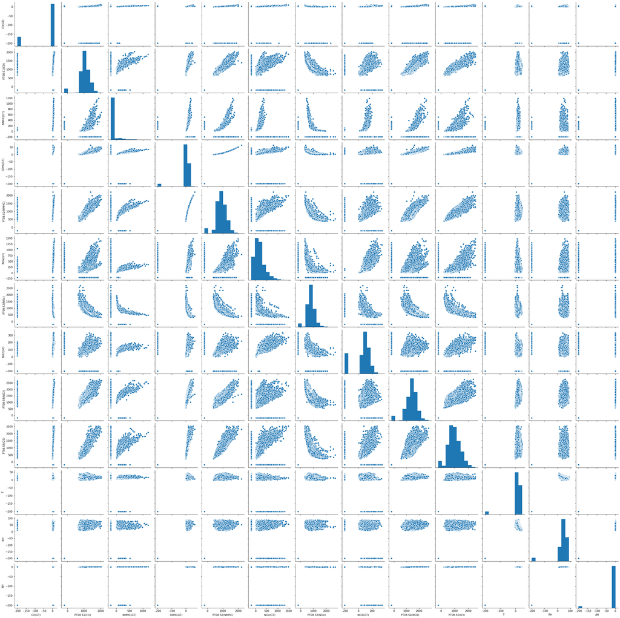

```python
sns.pairplot(df)
```

**The correlation between different features by using heatmap**

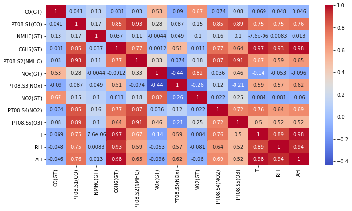

```python
plt.figure(figsize=(12,6))
sns.heatmap(df.corr(),cmap='coolwarm',annot=True)
```

# Preprocessing Data

**The first five rows of the dataset**

```python
df.head()
```

|  | Date | Time | CO(GT) | PT08.S1(CO) | NMHC(GT) | C6H6(GT) | PT08.S2(NMHC) | NOx(GT) | PT08.S3(NOx) | NO2(GT) | PT08.S4(NO2) | PT08.S5(O3) | T | RH | AH |
| --- | --- | --- | --- | --- | --- | --- | --- | --- | --- | --- | --- | --- | --- | --- | --- |
| 0 | 2004-03-10 | 18:00:00 | 2.6 | 1360.00 | 150 | 11.881723 | 1045.50 | 166.0 | 1056.25 | 113.0 | 1692.00 | 1267.50 | 13.60 | 48.875001 | 0.757754 |
| 1 | 2004-03-10 | 19:00:00 | 2.0 | 1292.25 | 112 | 9.397165 | 954.75 | 103.0 | 1173.75 | 92.0 | 1558.75 | 972.25 | 13.30 | 47.700000 | 0.725487 |
| 2 | 2004-03-10 | 20:00:00 | 2.2 | 1402.00 | 88 | 8.997817 | 939.25 | 131.0 | 1140.00 | 114.0 | 1554.50 | 1074.00 | 11.90 | 53.975000 | 0.750239 |
| 3 | 2004-03-10 | 21:00:00 | 2.2 | 1375.50 | 80 | 9.228796 | 948.25 | 172.0 | 1092.00 | 122.0 | 1583.75 | 1203.25 | 11.00 | 60.000000 | 0.786713 |
| 4 | 2004-03-10 | 22:00:00 | 1.6 | 1272.25 | 51 | 6.518224 | 835.50 | 131.0 | 1205.00 | 116.0 | 1490.00 | 1110.00 | 11.15 | 59.575001 | 0.788794 |

# Features vs Labels

```python
features=df
features
```

|  | Date | Time | CO(GT) | PT08.S1(CO) | NMHC(GT) | C6H6(GT) | PT08.S2(NMHC) | NOx(GT) | PT08.S3(NOx) | NO2(GT) | PT08.S4(NO2) | PT08.S5(O3) | T | RH | AH |
| --- | --- | --- | --- | --- | --- | --- | --- | --- | --- | --- | --- | --- | --- | --- | --- |
| 0 | 2004-03-10 | 18:00:00 | 2.6 | 1360.00 | 150 | 11.881723 | 1045.50 | 166.0 | 1056.25 | 113.0 | 1692.00 | 1267.50 | 13.600 | 48.875001 | 0.757754 |
| 1 | 2004-03-10 | 19:00:00 | 2.0 | 1292.25 | 112 | 9.397165 | 954.75 | 103.0 | 1173.75 | 92.0 | 1558.75 | 972.25 | 13.300 | 47.700000 | 0.725487 |
| 2 | 2004-03-10 | 20:00:00 | 2.2 | 1402.00 | 88 | 8.997817 | 939.25 | 131.0 | 1140.00 | 114.0 | 1554.50 | 1074.00 | 11.900 | 53.975000 | 0.750239 |
| 3 | 2004-03-10 | 21:00:00 | 2.2 | 1375.50 | 80 | 9.228796 | 948.25 | 172.0 | 1092.00 | 122.0 | 1583.75 | 1203.25 | 11.000 | 60.000000 | 0.786713 |
| 4 | 2004-03-10 | 22:00:00 | 1.6 | 1272.25 | 51 | 6.518224 | 835.50 | 131.0 | 1205.00 | 116.0 | 1490.00 | 1110.00 | 11.150 | 59.575001 | 0.788794 |
| ... | ... | ... | ... | ... | ... | ... | ... | ... | ... | ... | ... | ... | ... | ... | ... |
| 9352 | 2005-04-04 | 10:00:00 | 3.1 | 1314.25 | -200 | 13.529605 | 1101.25 | 471.7 | 538.50 | 189.8 | 1374.25 | 1728.50 | 21.850 | 29.250000 | 0.756824 |
| 9353 | 2005-04-04 | 11:00:00 | 2.4 | 1162.50 | -200 | 11.355157 | 1027.00 | 353.3 | 603.75 | 179.2 | 1263.50 | 1269.00 | 24.325 | 23.725000 | 0.711864 |
| 9354 | 2005-04-04 | 12:00:00 | 2.4 | 1142.00 | -200 | 12.374538 | 1062.50 | 293.0 | 603.25 | 174.7 | 1240.75 | 1092.00 | 26.900 | 18.350000 | 0.640649 |
| 9355 | 2005-04-04 | 13:00:00 | 2.1 | 1002.50 | -200 | 9.547187 | 960.50 | 234.5 | 701.50 | 155.7 | 1041.00 | 769.75 | 28.325 | 13.550000 | 0.513866 |
| 9356 | 2005-04-04 | 14:00:00 | 2.2 | 1070.75 | -200 | 11.932060 | 1047.25 | 265.2 | 654.00 | 167.7 | 1128.50 | 816.00 | 28.500 | 13.125000 | 0.502804 |

9357 rows × 15 columns

**Setting up the features**

```python
features=features.drop('Date',axis=1)
features=features.drop('Time',axis=1)
features=features.drop('C6H6(GT)',axis=1)
features=features.drop('PT08.S4(NO2)',axis=1)
```

**Setting up the target variable**

```python
labels=df['C6H6(GT)'].values
labels
```

```
array([11.88172349,  9.39716489,  8.99781687, ..., 12.3745384 ,
        9.54718667, 11.9320599 ])
```

```python
features=features.values
```

# Building models on the data

**Splitting the data for training and testing**

```python
from sklearn.model_selection import train_test_split
x_train, x_test, y_train, y_test = train_test_split(features, labels, test_size=0.3)
print(x_train.shape,y_train.shape,x_test.shape,y_test.shape)
```

```
(6549, 11) (6549,) (2808, 11) (2808,)
```

# Linear Regression

```python
from sklearn.linear_model import LinearRegression
lr = LinearRegression()
lr.fit(x_train, y_train)
```

```
LinearRegression()
```

**Predicting...**

```python
lr_pred=lr.predict(x_test)
```

```python
predicted=pd.DataFrame({'Predicted Data':lr_pred,'Actual Data':y_test})
predicted
```

|  | Predicted Data | Actual Data |
| --- | --- | --- |
| 0 | 1.163239 | 2.243255 |
| 1 | 1.048401 | 1.941878 |
| 2 | 38.332038 | 45.893520 |
| 3 | 3.424937 | 4.050257 |
| 4 | 19.272422 | 19.290975 |
| ... | ... | ... |
| 2803 | 9.418182 | 8.864233 |
| 2804 | 26.041872 | 28.790187 |
| 2805 | 1.889501 | 2.775808 |
| 2806 | 17.083439 | 17.431862 |
| 2807 | 13.831810 | 13.182230 |

2808 rows × 2 columns

**RMSE for Linear Regression**

```python
from sklearn.metrics import mean_squared_error
rmse_lr=np.sqrt(mean_squared_error(lr_pred,y_test))
rmse_lr
```

```
1.2344789692423377
```

**R2_Score for Linear Regression**

```python
from sklearn.metrics import r2_score
lr_r2_sc=r2_score(lr_pred,y_test)
lr_r2_sc
```

```
0.9990198269302517
```

# KNN Regression

```python
from sklearn.neighbors import KNeighborsRegressor
knr = KNeighborsRegressor(metric='euclidean')
knr.fit(x_train,y_train)
```

```
KNeighborsRegressor(metric='euclidean')
```

**Predicting...**

```python
knr_pred=knr.predict(x_test)
```

```python
predicted=pd.DataFrame({'Predicted Data':knr_pred,'Actual Data':y_test})
predicted
```

|  | Predicted Data | Actual Data |
| --- | --- | --- |
| 0 | 2.299591 | 2.243255 |
| 1 | 2.003883 | 1.941878 |
| 2 | 43.449084 | 45.893520 |
| 3 | 4.163692 | 4.050257 |
| 4 | 19.305543 | 19.290975 |
| ... | ... | ... |
| 2803 | 8.858827 | 8.864233 |
| 2804 | 27.153656 | 28.790187 |
| 2805 | 3.200131 | 2.775808 |
| 2806 | 17.105613 | 17.431862 |
| 2807 | 12.888873 | 13.182230 |

2808 rows × 2 columns

**RMSE for KNN Regression**

```python
from sklearn.metrics import mean_squared_error
rmse_knr=np.sqrt(mean_squared_error(knr_pred,y_test))
rmse_knr
```

```
0.8092969958904647
```

**R2_Score for KNN Regression**

```python
from sklearn.metrics import r2_score
knr_r2_sc=r2_score(knr_pred,y_test)
knr_r2_sc
```

```
0.999577731814817
```

# Decision Tree Regression

```python
from sklearn.tree import DecisionTreeRegressor
dtr = DecisionTreeRegressor()
dtr.fit(x_train, y_train)
```

```
DecisionTreeRegressor()
```

**Predicting...**

```python
dtr_pred = dtr.predict(x_test)
```

**Determining the dtr score**

```python
dtr_score=dtr.score(x_train, y_train)
dtr_score
```

```
1.0
```

```python
predicted=pd.DataFrame({'Predicted Data':dtr_pred,'Actual Data':y_test})
predicted
```

|  | Predicted Data | Actual Data |
| --- | --- | --- |
| 0 | 2.243255 | 2.243255 |
| 1 | 1.940772 | 1.941878 |
| 2 | 45.855181 | 45.893520 |
| 3 | 4.050257 | 4.050257 |
| 4 | 19.290975 | 19.290975 |
| ... | ... | ... |
| 2803 | 8.864233 | 8.864233 |
| 2804 | 28.874060 | 28.790187 |
| 2805 | 2.779675 | 2.775808 |
| 2806 | 17.440323 | 17.431862 |
| 2807 | 13.182230 | 13.182230 |

2808 rows × 2 columns

**RMSE for Decision Tree Regression**

```python
from sklearn.metrics import mean_squared_error
rmse_dtr=np.sqrt(mean_squared_error(dtr_pred,y_test))
rmse_dtr
```

```
0.22956562860215923
```

**R2_Score for Decision Tree Regression**

```python
from sklearn.metrics import r2_score
dtr_r2_sc=r2_score(dtr_pred,y_test)
dtr_r2_sc
```

```
0.9999661263412516
```

# Comparison and Conclusion

```python
metric_acc=pd.DataFrame({"LR":lr_r2_sc,"KNR":knr_r2_sc,"DTR":dtr_r2_sc},index=[1,2])
metric_acc
```

|  | LR | KNR | DTR |
| --- | --- | --- | --- |
| 1 | 0.99902 | 0.999578 | 0.999966 |
| 2 | 0.99902 | 0.999578 | 0.999966 |

**Comparing the "R2_Scores" of all the three processes**

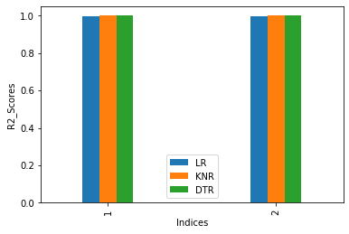

```python
#plt.figure(figsize=(12,6))
metric_acc.plot(y=["LR", "KNR", "DTR"], kind="bar",width=0.3)
plt.ylabel('R2_Scores')
plt.xlabel('Indices')
plt.show()
```

By looking at the bars and r2_score values of three different processes ,it can be said "Decision Tree Regressor (DTR) " is providing with the highest R2_Score.

# Hence, the "Decision Tree Regressor" is considered as the best fit for this problem.